# GARDEN 2A - Stumpers

2025-05-09

# Overview

# Set up

Load packages, ggplot themes, etc.

# Import data

We only analyse included trials

```r
df.stumpers <- read_csv(here('results/csv/stumpers_trial-responses-included.csv')) %>%
  mutate(is_correct = ifelse(response_category =='target_solution', 1, 0),
         is_correct_alternate = ifelse(response_category %in% c('target_solution', 'alternative_solution'), 1, 0),
         is_incorrect = ifelse(response_category %in% c('incorrect_response', 'incorrect_noresponse'), 1, 0),
         response_category = factor(response_category,
                                     levels=c('target_solution',
                                              'alternative_solution',
                                              'incorrect_response',
                                              'incorrect_noresponse')),
         parentScore = ifelse(parentCode=='similar',1, 0),
         parentCode = factor(parentCode,
                                levels=c('similar',
                                         'different',
                                         'no_answer')),
        trial_order_within_set = (trial_num -1) %% 3, # 0 = first, 1 = second, 2 = third
        set_order = floor((trial_num-1)/3)) # 0 = first, 1 = second, 2 = third
```

### Sanity checks

Check each participant contributes exactly one session, no repeats: - There are 172 unique children in the dataset.

Check number of trials contributed by participant

```r
df.stumpers %>%
  count(child_hashed_id) %>%
  count(n)
```

| n | nn |
| --- | --- |
| 6 | 3 |
| 7 | 14 |
| 8 | 32 |
| 9 | 123 |

Check response scoring

```r
df.stumpers %>% count(response_category, is_correct, is_correct_alternate)
```

| response_category | is_correct | is_correct_alternate | n |
| --- | --- | --- | --- |
| target_solution | 1 | 1 | 275 |
| alternative_solution | 0 | 1 | 136 |
| incorrect_response | 0 | 0 | 848 |
| incorrect_noresponse | 0 | 0 | 220 |

check trial numbers

```r
df.stumpers %>% count(trial_num, trial_order_within_set)
```

| trial_num | trial_order_within_set | n |
| --- | --- | --- |
| 1 | 0 | 145 |
| 2 | 1 | 160 |
| 3 | 2 | 169 |
| 4 | 0 | 165 |
| 5 | 1 | 169 |
| 6 | 2 | 167 |
| 7 | 0 | 167 |
| 8 | 1 | 170 |
| 9 | 2 | 167 |

### Item randomization check

How many responses per riddle?

```r
df.stumpers %>% count(question_set, question_id)
```

| question_set | question_id | n |
| --- | --- | --- |
| container | bucket | 165 |
| container | cup | 165 |
| container | potato | 164 |
| gender | basketball | 160 |
| gender | firefighter | 166 |
| gender | teacher | 163 |
| viewing | bedroom | 168 |
| viewing | cow | 165 |
| viewing | keys | 163 |

Were question sets randomly shuffled ?

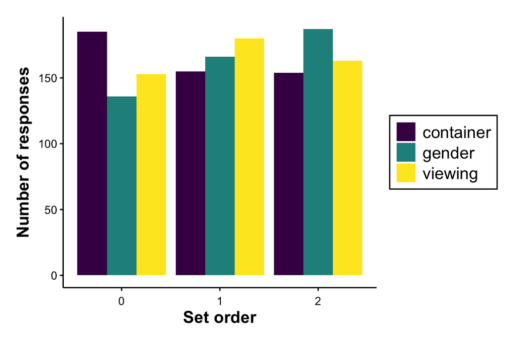

```r
df.stumpers %>% count(question_set, set_order) %>%
  ggplot(aes(x=set_order, y=n, fill=question_set)) +
  geom_col(position = "dodge" ) +
  labs(x="Set order", y="Number of responses") +
  scale_fill_viridis_d()
```

Were items evenly distributed to trial numbers within set?

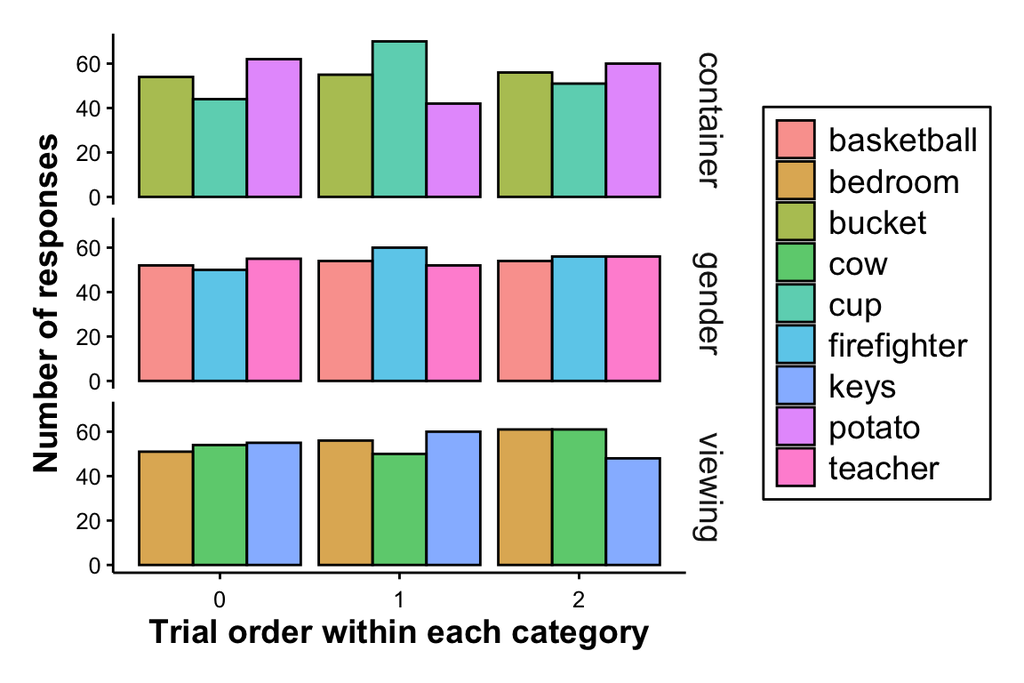

```r
df.stumpers %>% group_by(question_set) %>%
  count(question_id, trial_order_within_set) %>%
  ggplot(aes(x=trial_order_within_set, y=n, fill=question_id)) +
  geom_col(position = "dodge", alpha=0.7, color="black" ) +
  labs(x="Trial order within each category", y="Number of responses") +
  facet_grid(question_set~.)
```

Were items evenly distributed to trial numbers overall?

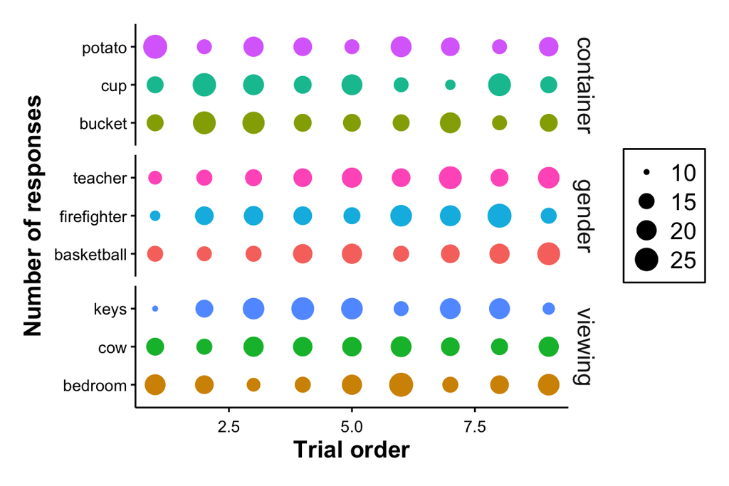

```r
df.stumpers %>%
  count(question_set, question_id, trial_num, trial_order_within_set, set_order) %>%
  ggplot(aes(x=trial_num, y=question_id, color=question_id, size = n)) +
  geom_point() +
  labs(x="Trial order", y="Number of responses") +
  facet_grid(question_set~., scales = "free") +
  guides(color = "none")
```

## Create child-level aggregates

```r
df.stumpers.bychild <-
  df.stumpers %>%
  group_by(child_hashed_id, age_months) %>%
  summarize(n_trials_included = n(),
            n_correct = sum(is_correct, na.rm=T),
            n_parent_correct = sum(parentScore, na.rm=T),
            n_correct_alternate = sum(is_correct_alternate, na.rm=T),
            n_alternate = sum(response_category == 'alternative_solution', na.rm=T))

write_csv(df.stumpers.bychild, here("results", "csv/stumpers_bychild_data.csv"))
```

# Participants

### Exclusions

These are detailed in `exclusions.R`

## Included participant demographics

### Age

```r
df.stumpers %>% select(child_hashed_id, age_months) %>% distinct() %>%
  summarize(
    n = n(),
    m_age = mean(age_months, na.rm=T),
    sd_age = sd(age_months, na.rm=T),
    min_age = min(age_months, na.rm=T),
    max_age = max(age_months, na.rm = T)
  )
```

| n | m_age | sd_age | min_age | max_age |
| --- | --- | --- | --- | --- |
| 172 | 65.16 | 13.96 | 39 | 92 |

### Gender

```r
df.stumpers %>% select(child_hashed_id, child_gender) %>% distinct() %>%
  count(child_gender)
```

| child_gender | n |
| --- | --- |
| f | 89 |
| m | 82 |
| o | 1 |

### Languages:

```r
df.stumpers %>% select(child_hashed_id, child__language_list) %>%
  distinct() %>%
  count(child__language_list)
```

| child__language_list | n |
| --- | --- |
| en | 121 |
| en bn he | 1 |
| en bn hi es | 1 |
| en cmn vi | 1 |
| en de | 3 |
| en de es | 1 |
| en es | 4 |
| en fr | 5 |
| en fr ru | 1 |
| en gu hi | 1 |

[output cut: 20 more lines]

### Race/Ethnicity:

# Descriptives

## All trials combined

(1479 items) Trials:

```r
# Response category proportions
df.stumpers %>%
  count(response_category) %>%
  mutate(prop = n / sum(n))
```

| response_category | n | prop |
| --- | --- | --- |
| target_solution | 275 | 0.18594 |
| alternative_solution | 136 | 0.09195 |
| incorrect_response | 848 | 0.57336 |
| incorrect_noresponse | 220 | 0.14875 |

```r
# Individual performance summary
df.stumpers.bychild %>%
  tidyboot_mean(n_correct)
```

| child_hashed_id | n | empirical_stat | ci_lower | mean | ci_upper |
| --- | --- | --- | --- | --- | --- |
| 27UZ6R | 1 | 2 | 2 | 2 | 2 |
| 2GZTVD | 1 | 3 | 3 | 3 | 3 |
| 2JQAKH | 1 | 1 | 1 | 1 | 1 |
| 2MQ5H5 | 1 | 1 | 1 | 1 | 1 |
| 2SYNHX | 1 | 1 | 1 | 1 | 1 |
| 2WAYCJ | 1 | 4 | 4 | 4 | 4 |
| 2cBHE2 | 1 | 0 | 0 | 0 | 0 |
| 3BcZWC | 1 | 0 | 0 | 0 | 0 |
| 3MQSGB | 1 | 3 | 3 | 3 | 3 |
| 3RUU2K | 1 | 2 | 2 | 2 | 2 |

[output cut: 162 more lines]

Individual children provide target solution on median of 1out of 9 trials (Mean = 1.5988, SD = 1.5089)

```r
# Summary stats
df.stumpers %>%
  group_by(child_hashed_id) %>%
  summarise(n_target = sum(response_category == "target_solution")) %>%
  summarise(
    median = median(n_target),
    mean = round(mean(n_target), 2),
    sd = round(sd(n_target), 2)
  )
```

| median | mean | sd |
| --- | --- | --- |
| 1 | 1.6 | 1.51 |

We can see this as a histogram:

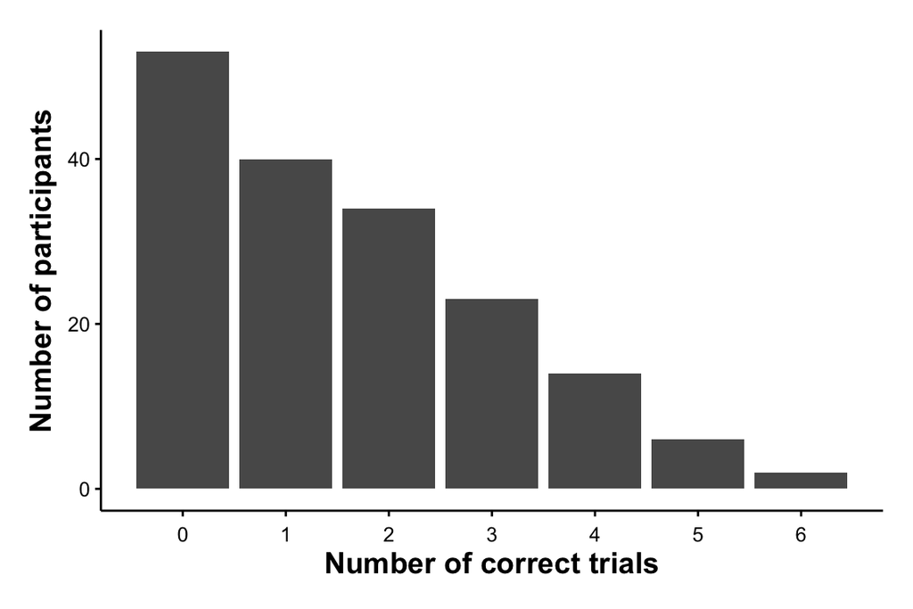

```r
df.stumpers.bychild %>%
  ggplot(aes(n_correct)) +
  geom_bar() +
  scale_x_continuous(breaks=seq(0,9,1)) +
  labs(x="Number of correct trials", y = "Number of participants")
```

### by question category

```r
# Category performance
df.stumpers %>% group_by(question_set) %>%
  tidyboot_mean(is_correct, na.rm=T)
```

| question_set | n | empirical_stat | ci_lower | mean | ci_upper |
| --- | --- | --- | --- | --- | --- |
| container | 494 | 0.1700 | 0.1370 | 0.1697 | 0.2017 |
| gender | 489 | 0.1391 | 0.1078 | 0.1391 | 0.1714 |
| viewing | 496 | 0.2480 | 0.2125 | 0.2482 | 0.2866 |

```r
# Chi-square test - differences between categories
df.stumpers %>%
  group_by(question_set) %>%
  summarize(
    correct = sum(response_category == "target_solution"),
    incorrect = n() - sum(response_category == "target_solution")) %>%
 select(correct, incorrect) %>%
 chisq.test()
```

```
##
##  Pearson's Chi-squared test
##
## data:  .
## X-squared = 21, df = 2, p-value = 3e-05
```

### By riddle

```r
df.stumpers %>% group_by(question_set, question_id) %>%
  tidyboot_mean(is_correct, na.rm=T)
```

| question_set | question_id | n | empirical_stat | ci_lower | mean | ci_upper |
| --- | --- | --- | --- | --- | --- | --- |
| container | bucket | 165 | 0.33333 | 0.26087 | 0.33315 | 0.4083 |
| container | cup | 165 | 0.09697 | 0.05417 | 0.09708 | 0.1429 |
| container | potato | 164 | 0.07927 | 0.04142 | 0.07911 | 0.1205 |
| gender | basketball | 160 | 0.15625 | 0.10145 | 0.15595 | 0.2139 |
| gender | firefighter | 166 | 0.15060 | 0.09603 | 0.14927 | 0.2050 |
| gender | teacher | 163 | 0.11043 | 0.06534 | 0.11136 | 0.1589 |
| viewing | bedroom | 168 | 0.14881 | 0.09657 | 0.14873 | 0.2048 |
| viewing | cow | 165 | 0.27879 | 0.21018 | 0.27897 | 0.3462 |
| viewing | keys | 163 | 0.31902 | 0.25316 | 0.32059 | 0.3933 |

Overall performance by riddle visualized

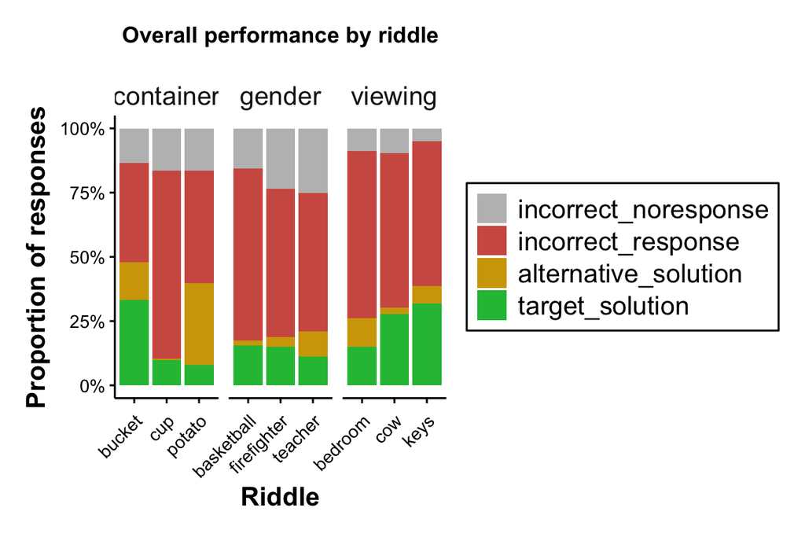

```r
df.stumpers %>%
  ggplot() +
  geom_bar(aes(x=question_id, fill=forcats::fct_rev(response_category)), position="fill") +
  facet_wrap(.~ question_set, scales = "free_x") +
  scale_y_continuous(labels = scales::percent) +
  scale_x_discrete(guide = guide_axis(angle = 45)) +
  labs(x="Riddle", y="Proportion of responses", title = "Overall performance by riddle") +
  scale_fill_manual(values=c("target_solution"="#26bd44",
                             "alternative_solution" = "#d1a402",
                             "incorrect_response"="#d15c51",
                             "incorrect_noresponse"="grey"))
```

## Trial 1

```r
df.stumpers.trial1 <- filter(df.stumpers, trial_num==1)
```

There are 145 included responses for trial 1.

```r
df.stumpers.trial1 %>%
  group_by(response_category) %>%
  summarise(
    n = n(),
    prop = n/nrow(filter(df.stumpers, trial_num == 1)) * 100
  ) %>%
  arrange(desc(prop))
```

| response_category | n | prop |
| --- | --- | --- |
| incorrect_response | 90 | 62.069 |
| incorrect_noresponse | 31 | 21.379 |
| alternative_solution | 13 | 8.966 |
| target_solution | 11 | 7.586 |

This is not evenly distributed by response category

```r
# Chi-square test - 1st trial
with(df.stumpers.trial1, {
  tab <- table(response_category)
  chisq.test(tab)})
```

```
##
##  Chi-squared test for given probabilities
##
## data:  tab
## X-squared = 113, df = 3, p-value <2e-16
```

### First trial by question category

```r
df.stumpers.trial1 %>%
  group_by(question_set) %>%
  tidyboot_mean(is_correct, na.rm=T)
```

| question_set | n | empirical_stat | ci_lower | mean | ci_upper |
| --- | --- | --- | --- | --- | --- |
| container | 58 | 0.06897 | 0.01667 | 0.06901 | 0.14036 |
| gender | 39 | 0.02564 | 0.00000 | 0.02395 | 0.08333 |
| viewing | 48 | 0.12500 | 0.02853 | 0.12288 | 0.21739 |

### First trial by riddle

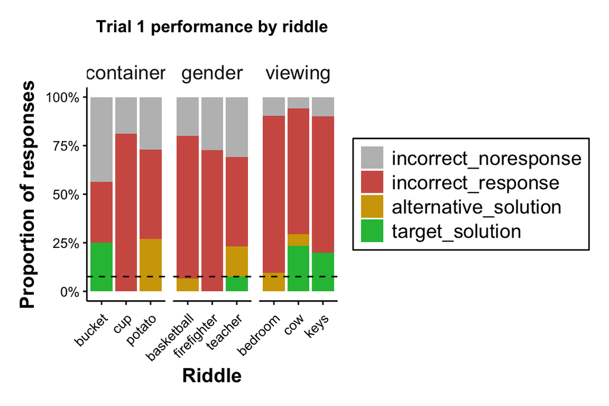

```r
df.stumpers.trial1 %>%
  ggplot() +
  geom_bar(aes(x=question_id, fill=forcats::fct_rev(response_category)), position="fill") +
  facet_wrap(.~ question_set, scales = "free_x") +
  scale_y_continuous(labels = scales::percent) +
  scale_x_discrete(guide = guide_axis(angle = 45)) +
  labs(x="Riddle", y="Proportion of responses", title = "Trial 1 performance by riddle") +
  scale_fill_manual(values=c("target_solution"="#26bd44",
                             "alternative_solution" = "#d1a402",
                             "incorrect_response"="#d15c51",
                             "incorrect_noresponse"="grey")) +
  geom_hline(yintercept = mean(df.stumpers.trial1$is_correct), linetype="dashed", color = "black")
```

### Binomial test w/ alternative solutions

```r
binom.test(sum(table(df.stumpers.trial1$response_category)[c("target_solution", "alternative_solution")]),
           length(df.stumpers.trial1$response_category),
           p = prop.table(table(df.stumpers.trial1$response_category))["target_solution"])
```

```
##
##  Exact binomial test
##
## data:  sum(table(df.stumpers.trial1$response_category)[c("target_solution", "alternative_solution")]) and length(df.stumpers.trial1$response_category)
## number of successes = 24, number of trials = 145, p-value = 4e-04
## alternative hypothesis: true probability of success is not equal to 0.07586
## 95 percent confidence interval:
##  0.1090 0.2362
## sample estimates:
## probability of success
##                 0.1655
```

## Trial 1 of each set

```r
df.stumpers%>%
  filter(trial_num %in% c(1, 4, 7)) %>%
  group_by(trial_num) %>%
  summarize(
    mean = mean(is_correct) * 100,
    sd = sd(is_correct) * 100
  )
```

| trial_num | mean | sd |
| --- | --- | --- |
| 1 | 7.586 | 26.57 |
| 4 | 9.091 | 28.84 |
| 7 | 14.371 | 35.19 |

## Trial effect

### Trial number within

```r
(df.stumpers.trialavg <- df.stumpers %>%
  filter(!is.na(is_correct)) %>%
  group_by(trial_num) %>%
  tidyboot_mean(is_correct, na.rm = TRUE))
```

| trial_num | n | empirical_stat | ci_lower | mean | ci_upper |
| --- | --- | --- | --- | --- | --- |
| 1 | 145 | 0.07586 | 0.03680 | 0.07665 | 0.1258 |
| 2 | 160 | 0.16250 | 0.10496 | 0.16050 | 0.2222 |
| 3 | 169 | 0.27219 | 0.20689 | 0.27516 | 0.3449 |
| 4 | 165 | 0.09091 | 0.04794 | 0.09038 | 0.1392 |
| 5 | 169 | 0.15976 | 0.10958 | 0.16161 | 0.2189 |
| 6 | 167 | 0.25749 | 0.18964 | 0.25659 | 0.3264 |
| 7 | 167 | 0.14371 | 0.08947 | 0.14427 | 0.2059 |
| 8 | 170 | 0.25882 | 0.18986 | 0.25916 | 0.3273 |
| 9 | 167 | 0.23353 | 0.16858 | 0.23247 | 0.2994 |

### Trial order within set

```r
df.stumpers %>%
  group_by(trial_order_within_set) %>%
  summarise(
    n = n(),  # number of participants
    mean = mean(response_category == "target_solution") * 100,
    sd = sd(response_category == "target_solution") * 100,
    .groups = "drop"
  ) %>%
  arrange(trial_order_within_set)
```

| trial_order_within_set | n | mean | sd |
| --- | --- | --- | --- |
| 0 | 477 | 10.48 | 30.66 |
| 1 | 499 | 19.44 | 39.61 |
| 2 | 503 | 25.45 | 43.60 |

### Trial order and age

compute mean accuracy for younger and older kids

```r
# two age groups using median split at 64 months
df.stumpers.trialavg.ages <-
  df.stumpers %>%
  mutate(correct = is_correct,
         age_bin = factor(age_months > 64,
                         labels = c("younger (3;3 - 5;4)", "older (5;5 - 7;7)"))
         ) %>%
  group_by(age_bin, trial_num) %>%
  tidyboot_mean(correct)

# Get counts by age group
df.stumpers %>%
  mutate(age_bin = factor(age_months > 64,
                         labels = c("younger (3;3 - 5;4)", "older (5;5 - 7;7)"))) %>%
  group_by(age_bin) %>%
  summarise(n = n_distinct(child_hashed_id))
```

| age_bin | n |
| --- | --- |
| younger (3;3 - 5;4) | 90 |
| older (5;5 - 7;7) | 82 |

# Main Results Figure

Plot with colored blocks

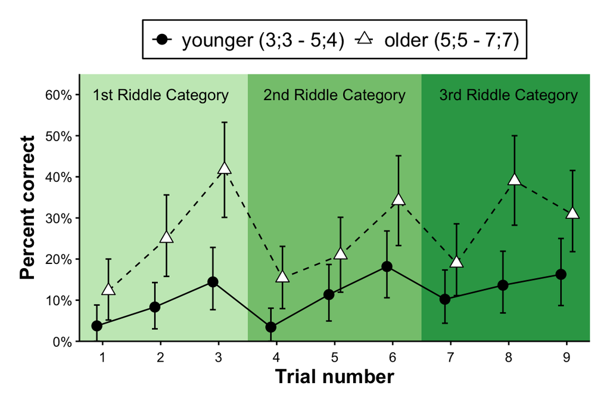

```r
mainfig <- df.stumpers.trialavg.ages %>%
  ggplot(aes(x = trial_num, y = empirical_stat,
             group = age_bin)) +
  annotate("rect", xmin = 0.5, xmax = 3.5, ymin = 0, ymax = 0.65, fill = "#c7e9c0") +
  annotate("text", x = 2, y = 0.6, label = "1st Riddle Category") +
  annotate("rect", xmin = 3.5, xmax = 6.5, ymin = 0, ymax = 0.65, fill = "#85C57D") +
  annotate("text", x = 5, y = 0.6, label = "2nd Riddle Category") +
  annotate("rect", xmin = 6.5, xmax = 9.5, ymin = 0, ymax = 0.65, fill = "#31a354") +
  annotate("text", x = 8, y = 0.6, label = "3rd Riddle Category") +
  geom_errorbar(aes(ymin = ci_lower, ymax = ci_upper),
                width = 0.2, color = "black",
                position = position_dodge(width=0.4)) +
  geom_line(aes(linetype = age_bin), color = "black",
            position = position_dodge(width=0.4)) +
  geom_point(aes(shape = age_bin), size = 3,
             color = "black", fill = "white",
             position = position_dodge(width=0.4)) +
  scale_linetype_manual(values = c("solid", "dashed")) +
  scale_shape_manual(values = c(19, 24)) +
  coord_cartesian(ylim=c(0,0.65), xlim = c(1,9)) +
  scale_y_continuous(labels = scales::percent,
                    breaks = seq(0, 0.8, by = 0.1),
                    expand = c(0,0)) +
  scale_x_continuous(breaks = 1:9, labels = 1:9) +
  labs(x = "Trial number",
       y = "Percent correct") +
  theme(legend.position = "top")

mainfig
```

```r
ggsave(plot=mainfig,
       here("results", "plots", "stumpers_accuracy_trials_age_lines_withlegend.pdf"), width=6, height=4,
       dpi=300)

# ggsave(plot = mainfig + theme(legend.position="none"),
#        here("results", "plots", "stumpers_accuracy_trials_age_lines.pdf"), width=6, height=3.5,
#        dpi=300)
```

# Preregistered Analyses

Our analysis approach is to use mixed-effects logistic regression to model trial-level accuracy (correct / not correct) as a function of trial number (within-block; factor; values 1 to 3), block number (factor; values 1 to 3), and age (in days, z-scored). To respect the repeated measures design, we will include a random subject intercept to account for variation in baseline accuracy for each participant, and a random item intercept to account for variation in baseline difficulty for each riddle.

```r
# Prepare data for models
df_model <- df.stumpers %>%
  select(child_hashed_id, age_months,
         question_set, question_id, trial_num,
         trial_order_within_set, set_order,
         is_correct, is_correct_alternate, is_incorrect) %>%
  mutate(age_scaled = scale(age_months),
         trial_order_within_set = as.integer(trial_order_within_set),
         set_order = as.integer(set_order),
         question_id = as.factor(question_id),
         child_hashed_id = as.factor(child_hashed_id))

# Verify coding
df_model %>% count(trial_num, set_order, trial_order_within_set)
```

| trial_num | set_order | trial_order_within_set | n |
| --- | --- | --- | --- |
| 1 | 0 | 0 | 145 |
| 2 | 0 | 1 | 160 |
| 3 | 0 | 2 | 169 |
| 4 | 1 | 0 | 165 |
| 5 | 1 | 1 | 169 |
| 6 | 1 | 2 | 167 |
| 7 | 2 | 0 | 167 |
| 8 | 2 | 1 | 170 |
| 9 | 2 | 2 | 167 |

Trial level accuracy, block no., and age model

```r
model_1 <- glmer(is_correct ~ trial_order_within_set * set_order + age_scaled + (1|child_hashed_id) + (1|question_id),
      family=binomial,
      data=df_model,
      glmerControl(optimizer = "bobyqa", optCtrl = list(maxfun = 100000)))

summary(model_1)
```

```
## Generalized linear mixed model fit by maximum likelihood (Laplace
##   Approximation) [glmerMod]
##  Family: binomial  ( logit )
## Formula: is_correct ~ trial_order_within_set * set_order + age_scaled +
##     (1 | child_hashed_id) + (1 | question_id)
##    Data: df_model
## Control: glmerControl(optimizer = "bobyqa", optCtrl = list(maxfun = 1e+05))
##
##      AIC      BIC   logLik deviance df.resid
##   1240.2   1277.3   -613.1   1226.2     1472
##
## Scaled residuals:
##    Min     1Q Median     3Q    Max
## -1.708 -0.459 -0.287 -0.148  6.144
##
## Random effects:
##  Groups          Name        Variance Std.Dev.
##  child_hashed_id (Intercept) 0.657    0.810
##  question_id     (Intercept) 0.491    0.701
## Number of obs: 1479, groups:  child_hashed_id, 172; question_id, 9
##
## Fixed effects:
##                                  Estimate Std. Error z value Pr(>|z|)
## (Intercept)                        -3.221      0.363   -8.87  < 2e-16 ***
## trial_order_within_set              0.939      0.167    5.61  2.1e-08 ***
## set_order                           0.511      0.174    2.93   0.0033 **
## age_scaled                          0.698      0.105    6.65  2.9e-11 ***
## trial_order_within_set:set_order   -0.253      0.119   -2.13   0.0332 *
## ---
## Signif. codes:  0 '***' 0.001 '**' 0.01 '*' 0.05 '.' 0.1 ' ' 1
##
## Correlation of Fixed Effects:
##             (Intr) trl___ st_rdr ag_scl
## trl_rdr_wt_ -0.637
## set_order   -0.601  0.731
## age_scaled  -0.143  0.078  0.032
## trl_rdr__:_  0.500 -0.815 -0.847 -0.024
```

Visualize model fixed effects estimates:

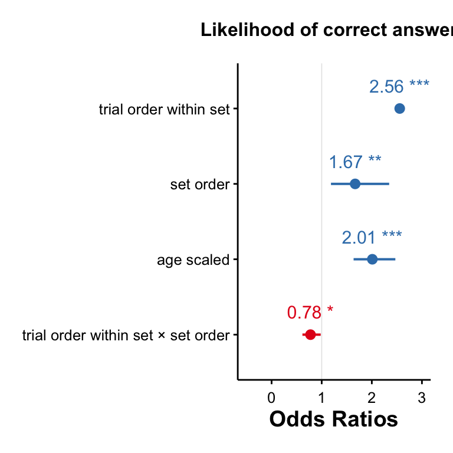

```r
plot_model(model_1, type="est", title = "Likelihood of correct answers",
           show.values = TRUE, value.offset = .3) + # print values above dots
  ylim(-0.5, 3)
```

View in tabular form as odds ratios:

```r
model_1.tidy <- tidy(model_1, conf.int = TRUE)

(model_1.tidyOR <- tidy(model_1, conf.int = TRUE, exponentiate = TRUE))
```

| effect | group | term | estimate | std.error | statistic | p.value | conf.low | conf.high |
| --- | --- | --- | --- | --- | --- | --- | --- | --- |
| fixed | NA | (Intercept) | 0.03992 | 0.01450 | -8.868 | 7.440e-19 | 0.01959 | 0.08135 |
| fixed | NA | trial_order_within_set | 2.55658 | 0.42794 | 5.608 | 2.050e-08 | 1.84153 | 3.54929 |
| fixed | NA | set_order | 1.66734 | 0.29053 | 2.934 | 3.347e-03 | 1.18496 | 2.34608 |
| fixed | NA | age_scaled | 2.01028 | 0.21109 | 6.650 | 2.932e-11 | 1.63635 | 2.46966 |
| fixed | NA | trial_order_within_set:set_order | 0.77652 | 0.09224 | -2.129 | 3.322e-02 | 0.61524 | 0.98007 |
| ran_pars | child_hashed_id | sd__(Intercept) | 0.81025 | NA | NA | NA | NA | NA |
| ran_pars | question_id | sd__(Intercept) | 0.70082 | NA | NA | NA | NA | NA |

Visualize model random effects on question id:

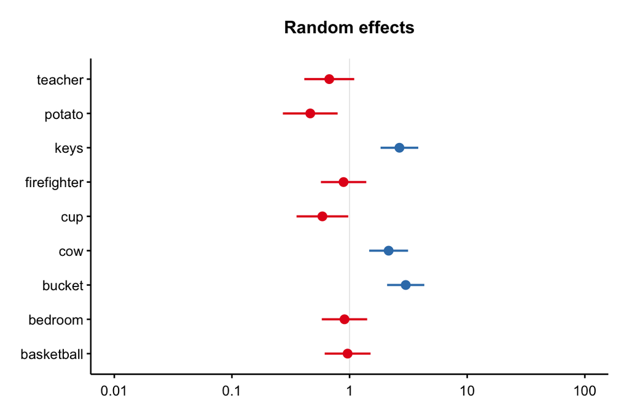

```r
plot_model(model_1, type = "re")[[2]]
```

## RQ1: Learning across trials, within category

*Our first question is whether riddle exposure leads children to learn ways of solving other riddles within a given category. We predict that children will show improvements in accuracy across trials within the same block. To assess this prediction, we will test whether the coefficient of trial number is greater than zero (one-tailed t-test).*

```r
model_1.tidyOR %>% filter(term == "trial_order_within_set")
```

| effect | group | term | estimate | std.error | statistic | p.value | conf.low | conf.high |
| --- | --- | --- | --- | --- | --- | --- | --- | --- |
| fixed | NA | trial_order_within_set | 2.557 | 0.4279 | 5.608 | 2.05e-08 | 1.842 | 3.549 |

*If this coefficient is significant, we will run follow-up pairwise contrasts (z-tests on log odds ratios between trials, tukey-adjusted p-values) to test for improvement between trials 1→2, 2→3, and 1→3.*

As we can see above, the coefficient of trial number is significant, indicating that children are more likely to answer correctly on later trials within a block.

Deviation: We coded trial & block number as numeric (not categorical), so the pairwise contrasts are not straightforward. Instead, we will inspect the empirical means for trial number:

```r
within_category_result <- model_1.tidyOR %>%
  filter(term == "trial_order_within_set") %>%
  mutate(
    ci_lower = conf.low,
    ci_upper = conf.high,
    p_formatted = if_else(p.value < 0.001,
                         "p < .001",
                         sprintf("p = %.3f", p.value)),
    result = sprintf("OR = %.2f, 95%% CI [%.2f, %.2f], %s",
                    estimate,
                    ci_lower,
                    ci_upper,
                    p_formatted)
  ) %>%
  pull(result)

cat("Within-category learning effect:", within_category_result, "\n")
```

```
## Within-category learning effect: OR = 2.56, 95% CI [1.84, 3.55], p < .001
```

```r
# Descriptive statistics by trial order
df.stumpers %>%
  group_by(trial_order_within_set) %>%
  summarise(
    n = n(),
    mean = mean(response_category == "target_solution") * 100,
    sd = sd(response_category == "target_solution") * 100,
    .groups = "drop"
  ) %>%
  arrange(trial_order_within_set)
```

| trial_order_within_set | n | mean | sd |
| --- | --- | --- | --- |
| 0 | 477 | 10.48 | 30.66 |
| 1 | 499 | 19.44 | 39.61 |
| 2 | 503 | 25.45 | 43.60 |

Inspect the empirical means for trial number:

```r
(means.trial_order <- (df_model %>%
  group_by(trial_order_within_set) %>%
  tidyboot_mean(is_correct)))
```

| trial_order_within_set | n | empirical_stat | ci_lower | mean | ci_upper |
| --- | --- | --- | --- | --- | --- |
| 0 | 477 | 0.1048 | 0.08132 | 0.1050 | 0.1318 |
| 1 | 499 | 0.1944 | 0.16135 | 0.1941 | 0.2288 |
| 2 | 503 | 0.2545 | 0.21748 | 0.2536 | 0.2929 |

#### Plot

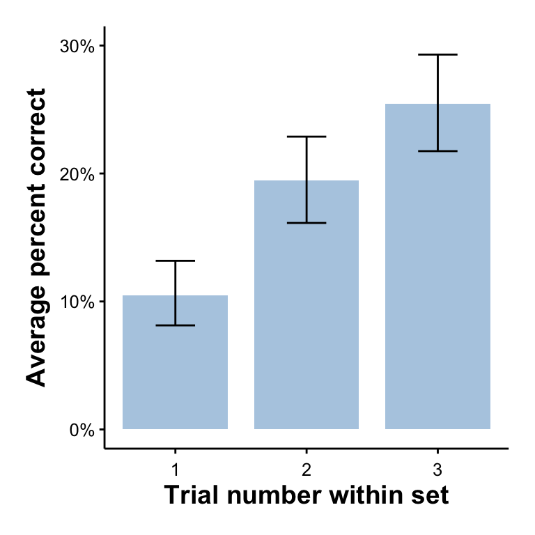

```r
means.trial_order %>%
  ggplot(aes(x = trial_order_within_set, y= empirical_stat)) +
  geom_bar(stat="identity", width=0.8, fill= '#B3CDE3') +
  geom_errorbar(aes(ymin=ci_lower, ymax=ci_upper), stat="identity", position="identity", width=0.3) +
  scale_x_continuous("Trial number within set", breaks=c(0,1,2), labels=c("1", "2", "3")) +
  scale_y_continuous("Average percent correct", labels = scales::percent,
                     limits=c(0,0.3))
```

```r
ggsave(here("results", "plots", "stumpers_trial_effect.pdf"),
dpi=300, width=3, height=3.5)
```

## RQ2: Improvement across categories

Our second question is whether children also show learning across riddle categories. We predict that children will show improvements in accuracy across blocks. That is, a riddle presented on later blocks should yield higher correct answers than the same riddle presented on block 1. To assess this prediction, we will test whether the slope of block number is positive (one-tailed t-test).

### RQ2.1 Improvement across categories

Extract odds ratio for across-set improvement

```r
model_1.tidyOR %>% filter(term == "set_order")
```

| effect | group | term | estimate | std.error | statistic | p.value | conf.low | conf.high |
| --- | --- | --- | --- | --- | --- | --- | --- | --- |
| fixed | NA | set_order | 1.667 | 0.2905 | 2.934 | 0.003347 | 1.185 | 2.346 |

*If there is a significant slope, we will run follow-up pairwise contrasts (z-tests on log odds ratios between blocks, tukey-adjusted p-values) to test for improvement between blocks 1→2, 2→3, and 1→3.*

As before, this pre-registered contrast doesn’t really make sense. Instead, inspect empirical means and CIs:

```r
df.stumpers %>%
  group_by(set_order) %>%
  summarise(
    n = n(),
    mean = mean(response_category == "target_solution") * 100,  # convert to percentage
    sd = sd(response_category == "target_solution") * 100,  # convert to percentage
    .groups = "drop"
  ) %>%
  arrange(set_order) %>%
  mutate(
    stats = sprintf("%.1f%% (SD = %.1f), n = %d", mean, sd, n)
  )
```

| set_order | n | mean | sd | stats |
| --- | --- | --- | --- | --- |
| 0 | 474 | 17.51 | 38.05 | 17.5% (SD = 38.0), n = 474 |
| 1 | 501 | 16.97 | 37.57 | 17.0% (SD = 37.6), n = 501 |
| 2 | 504 | 21.23 | 40.93 | 21.2% (SD = 40.9), n = 504 |

#### Plot:

```r
(means.set_order <- df_model %>%
  group_by(set_order) %>%
  tidyboot_mean(is_correct))
```

| set_order | n | empirical_stat | ci_lower | mean | ci_upper |
| --- | --- | --- | --- | --- | --- |
| 0 | 474 | 0.1751 | 0.1390 | 0.1743 | 0.2082 |
| 1 | 501 | 0.1697 | 0.1383 | 0.1696 | 0.2013 |
| 2 | 504 | 0.2123 | 0.1793 | 0.2123 | 0.2500 |

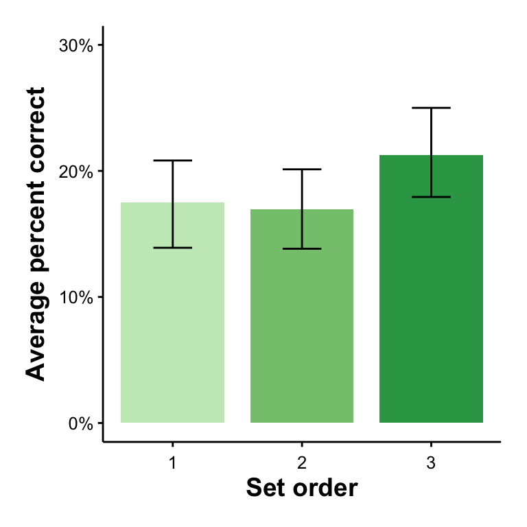

```r
means.set_order %>%
  ggplot(aes(x = set_order, y = empirical_stat,
             fill = factor(set_order),
             alpha = factor(set_order))) +
  geom_bar(stat = "identity", width = 0.8) +
  geom_errorbar(aes(ymin = ci_lower, ymax = ci_upper),
                stat = "identity",
                position = "identity",
                width = 0.3,
                alpha = 1) +
  scale_x_continuous("Set order",
                    breaks = c(0, 1, 2),
                    labels = c("1", "2", "3")) +
  scale_y_continuous("Average percent correct",
                    labels = scales::percent,
                    limits = c(0, 0.3)) +
  scale_fill_manual(values = c("#c7e9c0", "#85C57D", "#31a354"),
                    guide = "none") +
  scale_alpha_manual(values = c(1, 1, 1),
                    guide = "none")
```

```r
ggsave(here("results", "plots", "stumpers_setorder_effect.pdf"),
       dpi=300, width=3, height=3.5)
```

### RQ2.2 Interaction of block and trial number

We will also examine if there is an interaction between trial number and block number. While we do not have a specific prediction about this effect, it is possible, for example, that children show greater learning on later blocks. To assess this possibility, we will test if the regression model with a trial number by block number interaction is a better fit than the model without an interaction, based on a significant likelihood ratio test and lower AIC value. We will further characterize any significant interaction by inspecting model-estimated marginal means (i.e., model-predicted accuracy for all 9 trials).

```r
model_2 <- update(model_1, . ~ . - trial_order_within_set:set_order)
anova(model_1, model_2)
```

|  | npar | AIC | BIC | logLik | deviance | Chisq | Df | Pr(>Chisq) |
| --- | --- | --- | --- | --- | --- | --- | --- | --- |
| model_2 | 6 | 1243 | 1274 | -615.3 | 1231 | NA | NA | NA |
| model_1 | 7 | 1240 | 1277 | -613.1 | 1226 | 4.372 | 1 | 0.03654 |

There is a significant trial by set number interaction! Let’s visualize model predictions. In later blocks, the slope of trial number is flatter, indicating that children are improving slower on later blocks.

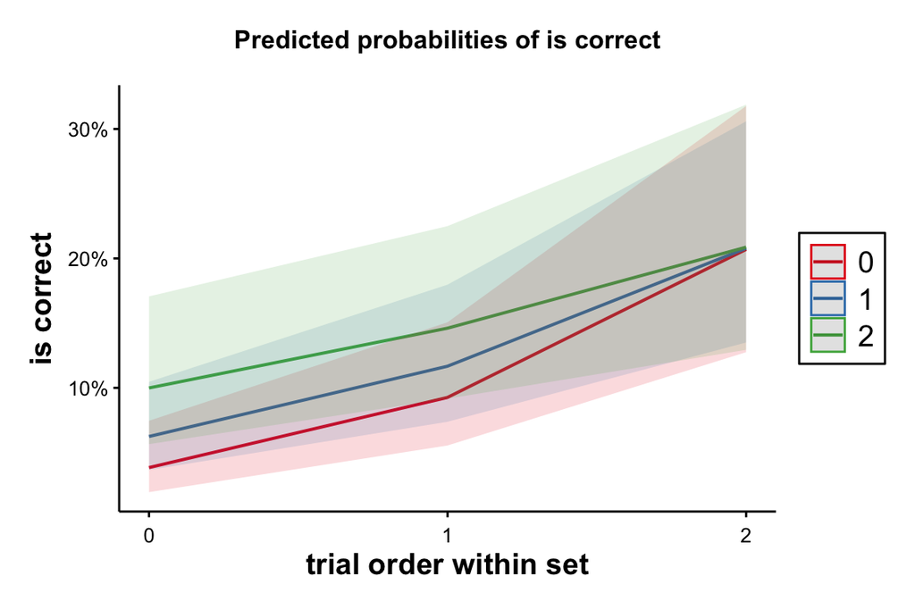

```r
plot_model(model_1, type="int",
           terms=c("trial_order_within_set", "set_order"),
           mdrt.values = "all") + # what levels of set order
  scale_x_continuous(breaks=c(0,1,2))
```

Means

```r
df.stumpers %>%
  filter(trial_order_within_set %in% c(0,2)) %>%
  group_by(set_order, trial_order_within_set) %>%
  summarize(
    n = n(),
    acc = mean(is_correct, na.rm=TRUE),
    .groups="drop"
  ) %>%
  pivot_wider(names_from = trial_order_within_set, values_from = c(n, acc)) %>%
  mutate(improvement_ratio = acc_2/acc_0)
```

| set_order | n_0 | n_2 | acc_0 | acc_2 | improvement_ratio |
| --- | --- | --- | --- | --- | --- |
| 0 | 145 | 169 | 0.07586 | 0.2722 | 3.588 |
| 1 | 165 | 167 | 0.09091 | 0.2575 | 2.832 |
| 2 | 167 | 167 | 0.14371 | 0.2335 | 1.625 |

#### First trial performance across blocks

```r
df.stumpers%>%
  filter(trial_num %in% c(1, 4, 7)) %>%
  group_by(trial_num) %>%
  summarize(
    mean = mean(is_correct) * 100,
    sd = sd(is_correct) * 100
  )
```

| trial_num | mean | sd |
| --- | --- | --- |
| 1 | 7.586 | 26.57 |
| 4 | 9.091 | 28.84 |
| 7 | 14.371 | 35.19 |

#### improvement rate by riddle category

```r
df.stumpers %>%
  filter(trial_order_within_set %in% c(0,2)) %>%
  group_by(question_set,trial_order_within_set) %>%
  summarize(
    n = n(),
    acc = mean(is_correct, na.rm=TRUE),
  )
```

| question_set | trial_order_within_set | n | acc |
| --- | --- | --- | --- |
| container | 0 | 160 | 0.13125 |
| container | 2 | 167 | 0.19162 |
| gender | 0 | 157 | 0.05096 |
| gender | 2 | 166 | 0.21084 |
| viewing | 0 | 160 | 0.13125 |
| viewing | 2 | 170 | 0.35882 |

## RQ3: Age

Finally, our third question concerns the developmental trajectory of accuracy, within-block learning, and across-block generalization.

#### Correlation, age and target solutions

```r
(age_corr <- cor.test(df.stumpers.bychild$age_months, df.stumpers.bychild$n_correct))
```

```
##
##  Pearson's product-moment correlation
##
## data:  df.stumpers.bychild$age_months and df.stumpers.bychild$n_correct
## t = 6.5, df = 170, p-value = 7e-10
## alternative hypothesis: true correlation is not equal to 0
## 95 percent confidence interval:
##  0.3206 0.5607
## sample estimates:
##    cor
## 0.4487
```

Correlation between age and target solutions: r = $r = .45$, 95% CI $[.32, .56]$, $t(170) = 6.55$, $p < .001$

#### Correlation, age and alternative solutions

Frequency of alternative solutions also increase with age: $r = .18$, 95% CI $[.03, .32]$, $t(170) = 2.39$, $p = .018$

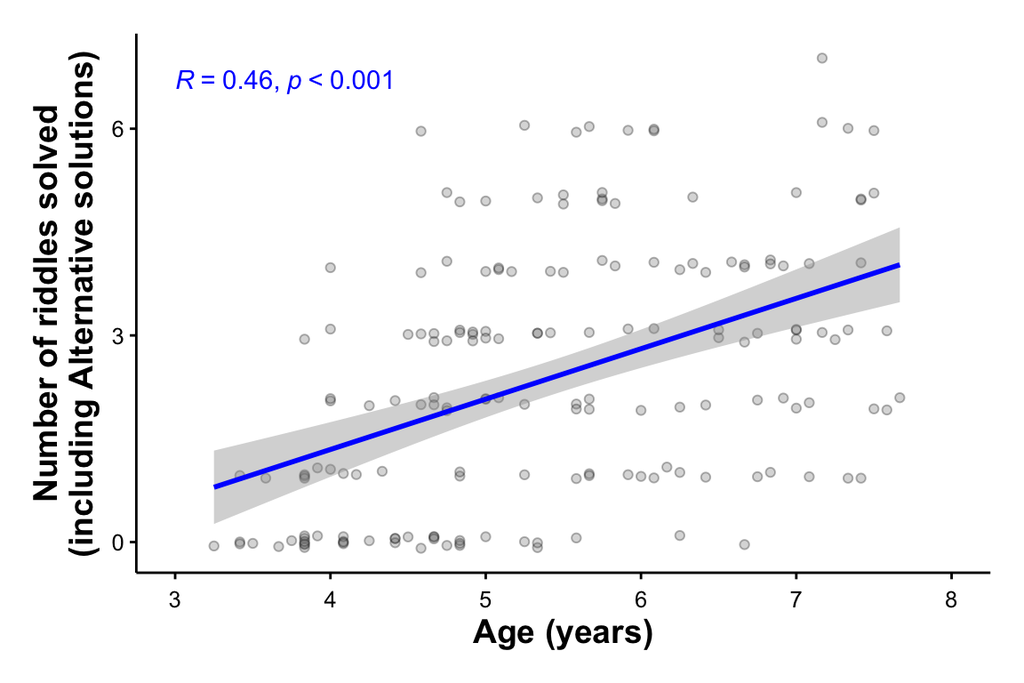

```r
df.stumpers.bychild %>%
  ggplot(aes(x=age_months, y=n_correct_alternate)) +
  geom_point(fill='grey50', shape=21, alpha=0.3,
             position = position_jitter(width=0, height=0.1)) +
  geom_smooth(method = lm, color = "blue", se=TRUE) +
  stat_cor(method="pearson", color = "blue",
           p.accuracy = 0.001, r.accuracy = 0.01) +
  scale_x_continuous(breaks=seq(36, 96, 12),
                     labels = seq(3,8,1),
                     limits = c(36, 96)) +
  scale_y_continuous(breaks=seq(0,9,3)) +
  labs(y="Number of riddles solved\n(including Alternative solutions)", x="Age (years)")
```

```r
# ggMarginal(p, type = "histogram")

# ggsave(here("results", "plots", "stumpers_accuracy_age_incl-alternate.pdf"),
#        width=4, height=3, dpi=300)
```

### RQ3.1 Age effects on overall accuracy

Extract model-estimated coefficient for age (scaled):

```r
# Extract coefficient for age
model_1.tidy %>% filter(term == "age_scaled")
```

| effect | group | term | estimate | std.error | statistic | p.value | conf.low | conf.high |
| --- | --- | --- | --- | --- | --- | --- | --- | --- |
| fixed | NA | age_scaled | 0.6983 | 0.105 | 6.65 | 2.932e-11 | 0.4925 | 0.9041 |

Convert to odds ratio: odds increase by 2x for every 1 SD increase in age.

```r
model_1.tidyOR %>% filter(term == "age_scaled")
```

| effect | group | term | estimate | std.error | statistic | p.value | conf.low | conf.high |
| --- | --- | --- | --- | --- | --- | --- | --- | --- |
| fixed | NA | age_scaled | 2.01 | 0.2111 | 6.65 | 2.932e-11 | 1.636 | 2.47 |

Here Age is z-scored, so let’s unscale it back to months for interpretation:

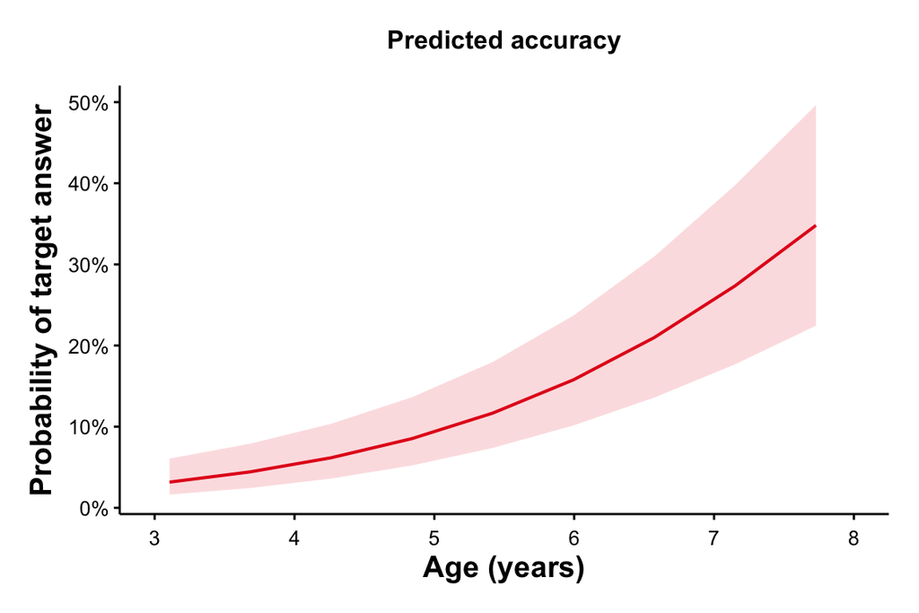

```r
scale_age <- function(age_months, scale, center) {
  (age_months - center) / scale
}

unscale_age <- function(age_months, scale, center) {
  age_months * scale + center
}

age.scaling_factor <- attr(df_model$age_scaled, 'scaled:scale')
age.center_factor <- attr(df_model$age_scaled, 'scaled:center')

plot_model(model_1, type="pred", terms = "age_scaled") +
  scale_x_continuous(limits = scale_age(c(36, 96), age.scaling_factor,age.center_factor),
                     breaks = scale_age(seq(36, 96, 12), age.scaling_factor,age.center_factor),
                     labels = seq(3, 8, 1)) +
  labs(x = "Age (years)", y = "Probability of target answer",
       title = "Predicted accuracy")
```

Plot individual - accuracy by age

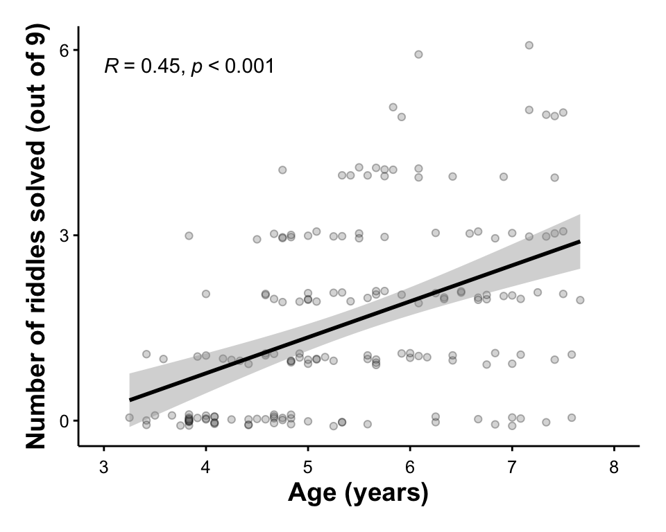

```r
p <- df.stumpers.bychild %>%
  ggplot(aes(x=age_months, y=n_correct)) +
  geom_point(fill='grey50', shape=21, alpha=0.3,
                          position = position_jitter(width=0, height=0.1)) +
  geom_smooth(method = lm, color = "black", se=TRUE) +
  stat_cor(method="pearson", color = "black",
           p.accuracy = 0.001, r.accuracy = 0.01) +
  scale_x_continuous(breaks=seq(36, 96, 12),
                     labels = seq(3,8,1),
                     limits = c(36, 96)) +
  scale_y_continuous(breaks=seq(0,9,3)) +
  labs(y="Number of riddles solved (out of 9)", x="Age (years)")

p
```

```r
# ggMarginal(p, type = "histogram")

ggsave(here("results", "plots", "stumpers_accuracy_age.pdf"),
       width=4, height=4, dpi=300)
```

Aggregating across trials, children produced the target solution on an average of 1.5988 riddles (SD = 1.5089 ) out of 9, with older children producing more target solutions (Pearson’s $r = .45$, 95% CI $[.32, .56]$, $t(170) = 6.55$, $p < .001$; age in months).

### RQ3.2 Age on first riddle

We will also repeat this analysis for just the very first riddle (holding trial_num = 1 and block_number = 1).

Plot data:

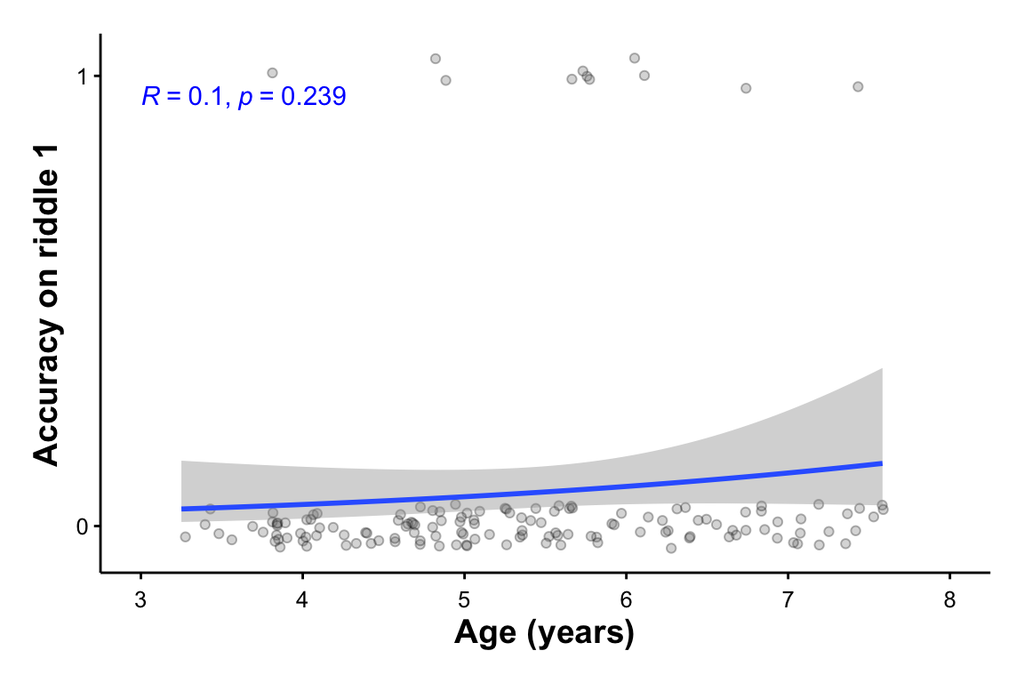

```r
df.stumpers.trial1 %>%
  ggplot(aes(x=age_months, y=is_correct)) +
  geom_jitter(height = 0.05, fill='grey50', shape=21, alpha=0.3) +
  geom_smooth(method = "glm", method.args = list(family = "binomial")) +
  stat_cor(method="pearson", color = "blue",
           p.accuracy = 0.001, r.accuracy = 0.01) +
  scale_x_continuous(breaks=seq(36, 96, 12),
                     labels = seq(3,8,1),
                     limits = c(36, 96)) +
  scale_y_continuous(breaks = c(0,1)) +
  labs(y="Accuracy on riddle 1", x="Age (years)")
```

```r
cor.test(df.stumpers.trial1$age_months, df.stumpers.trial1$is_correct)
```

```
##
##  Pearson's product-moment correlation
##
## data:  df.stumpers.trial1$age_months and df.stumpers.trial1$is_correct
## t = 1.2, df = 143, p-value = 0.2
## alternative hypothesis: true correlation is not equal to 0
## 95 percent confidence interval:
##  -0.06574  0.25721
## sample estimates:
##     cor
## 0.09832
```

### RQ3.3 Age * trial number

To test if age influences within-block learning, we will test if including an age by trial number interaction improves model fit (model comparison using likelihood ratio test).

```r
model_3 <- update(model_1, . ~ . + trial_order_within_set:age_scaled)
anova(model_1, model_3)
```

|  | npar | AIC | BIC | logLik | deviance | Chisq | Df | Pr(>Chisq) |
| --- | --- | --- | --- | --- | --- | --- | --- | --- |
| model_1 | 7 | 1240 | 1277 | -613.1 | 1226 | NA | NA | NA |
| model_3 | 8 | 1241 | 1284 | -612.7 | 1225 | 0.8433 | 1 | 0.3585 |

### RQ3.4 Age * block number

To test if age influences across-block generalization, we will test if including an age by block number interaction improves model fit (model comparison using likelihood ratio test).

```r
model_4 <- update(model_1, . ~ . + set_order:age_scaled)
anova(model_1, model_4)
```

|  | npar | AIC | BIC | logLik | deviance | Chisq | Df | Pr(>Chisq) |
| --- | --- | --- | --- | --- | --- | --- | --- | --- |
| model_1 | 7 | 1240 | 1277 | -613.1 | 1226 | NA | NA | NA |
| model_4 | 8 | 1242 | 1285 | -613.1 | 1226 | 0.06449 | 1 | 0.7995 |

Descriptives:

```r
df.stumpers %>%
  filter(set_order %in% c(0,1,2)) %>%
  group_by(set_order) %>%
  mutate(age_group_is_older = age_months >= median(age_months, na.rm=TRUE)) %>%
  group_by(age_group_is_older, set_order) %>%
  summarize(
    n = n(),
    acc = mean(is_correct, na.rm=TRUE),
  ) %>%
  pivot_wider(names_from = set_order, values_from = c(n, acc)) %>%
  mutate(improvement_ratio = acc_2/acc_0)
```

| age_group_is_older | n_0 | n_1 | n_2 | acc_0 | acc_1 | acc_2 | improvement_ratio |
| --- | --- | --- | --- | --- | --- | --- | --- |
| FALSE | 229 | 249 | 247 | 0.08297 | 0.1044 | 0.1296 | 1.561 |
| TRUE | 245 | 252 | 257 | 0.26122 | 0.2341 | 0.2918 | 1.117 |

# Exploratory analyses

## Shifts in response types over trials

If we find evidence for a learning effect (i.e., if performance improves over trials or blocks), we will run an exploratory analysis examining shifts in response types over trials. For example, improved performance might be due to an increase in the proportion of children giving any response at all (perhaps reflecting feeling less “stumped”), or it may be due to shifts in giving higher quality responses (i.e., increased proportion of correct or alternative solutions). We will use multinomial regression models to predict the likelihood of each response category from trial number and block number.

```r
df.stumpers %>%
  filter(trial_num %in% c(1,3)) %>%
  group_by(question_set) %>%
  mutate(age_group = age_months >= median(age_months, na.rm=TRUE)) %>%
  group_by(age_group, question_set, trial_num) %>%
  summarize(
    n = n(),  # add this to check our counts
    acc = mean(is_correct, na.rm=TRUE),
    .groups="drop"
  ) %>%
  pivot_wider(names_from = trial_num, values_from = c(n, acc)) %>%
  mutate(improvement_ratio = acc_3/acc_1)
```

| age_group | question_set | n_1 | n_3 | acc_1 | acc_3 | improvement_ratio |
| --- | --- | --- | --- | --- | --- | --- |
| FALSE | container | 29 | 30 | 0.03448 | 0.10000 | 2.900 |
| FALSE | gender | 18 | 21 | 0.05556 | 0.09524 | 1.714 |
| FALSE | viewing | 23 | 27 | 0.04348 | 0.33333 | 7.667 |
| TRUE | container | 29 | 34 | 0.10345 | 0.29412 | 2.843 |
| TRUE | gender | 21 | 29 | 0.00000 | 0.24138 | Inf |
| TRUE | viewing | 25 | 28 | 0.20000 | 0.53571 | 2.679 |

First let’s visualize these shifts

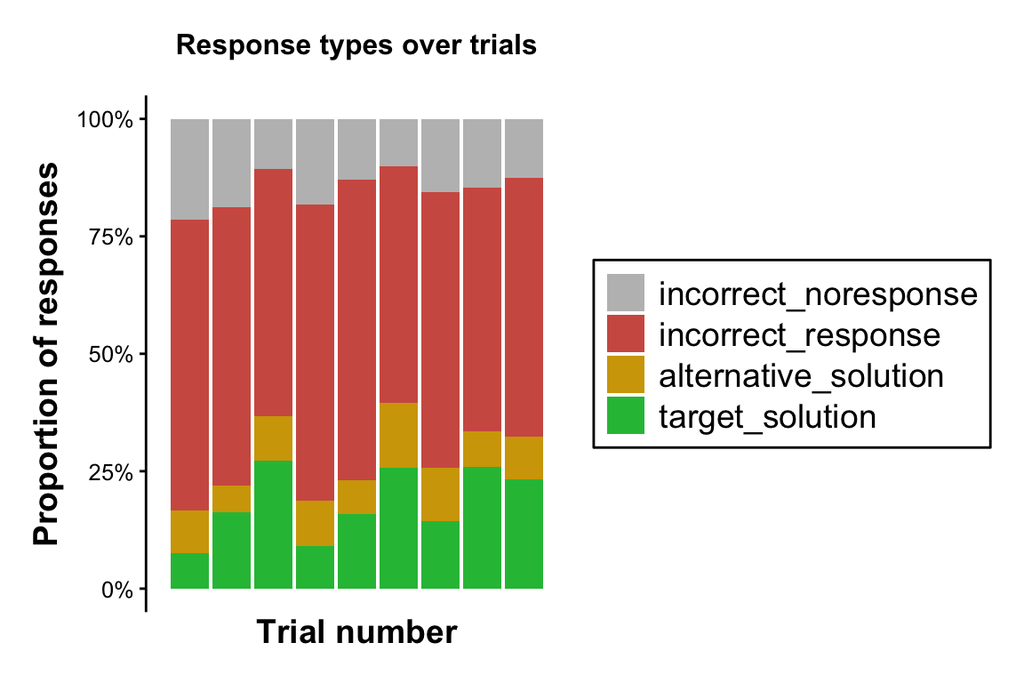

```r
df.stumpers %>%
  ggplot() +
  geom_bar(aes(x=trial_num, fill=forcats::fct_rev(response_category)), position="fill") +
  # facet_wrap(.~ question_set, scales = "free_x") +
  scale_y_continuous(labels = scales::percent) +
  scale_x_discrete(guide = guide_axis(angle = 45)) +
  labs(x="Trial number", y="Proportion of responses", title = "Response types over trials") +
  scale_fill_manual(values=c("target_solution"="#26bd44",
                             "alternative_solution" = "#d1a402",
                             "incorrect_response"="#d15c51",
                             "incorrect_noresponse"="grey"))
```

Hmm. Let’s look another way

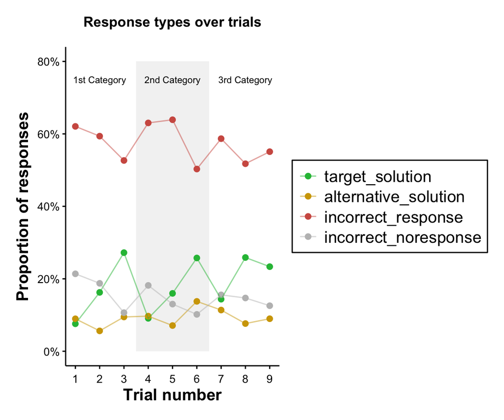

```r
df.stumpers %>%
  count(trial_num, response_category) %>%
  group_by(trial_num) %>%
  mutate(prop = n / sum(n)) %>%
  ggplot(aes(y = prop, x=trial_num, fill=response_category, color=response_category)) +
  # geom_vline(xintercept =3.5, alpha=0.2) +
  #   annotate("rect", xmin = 0.5, xmax = 3.5, ymin = 0, ymax = 0.8,
  #          alpha = .2, fill = "#e5f5f9") +
  annotate("text", x = 2, y = 0.75, label = "1st Category", size = 8/.pt) +
  annotate("rect", xmin = 3.5, xmax = 6.5, ymin = 0, ymax = 0.8,
           alpha = .2, fill = "grey75") +
  annotate("text", x = 5, y = 0.75, label = "2nd Category", size = 8/.pt) +
  # annotate("rect", xmin = 6.5, xmax = 9.5, ymin = 0, ymax = 0.8,
  #          alpha = .2, fill = "#7600cf") +
  annotate("text", x = 8, y = 0.75, label = "3rd Category", size = 8/.pt) +
  geom_point(shape=21, size=2)+
  geom_line(alpha=0.5) +
  # facet_wrap(.~ question_set, scales = "free_x") +
  scale_y_continuous(labels = scales::percent) +
  scale_x_continuous(breaks = seq(1,9),
                     labels = seq(1,9)) +
  labs(x="Trial number", y="Proportion of responses", title = "Response types over trials") +
  scale_fill_manual(values=c("target_solution"="#26bd44",
                             "alternative_solution" = "#d1a402",
                             "incorrect_response"="#d15c51",
                             "incorrect_noresponse"="grey")) +
  scale_color_manual(values=c("target_solution"="#26bd44",
                             "alternative_solution" = "#d1a402",
                             "incorrect_response"="#d15c51",
                             "incorrect_noresponse"="grey"))
```

```r
ggsave(here("results", "plots", "stumpers_response_types_over_trials.pdf"), width=6, height=4, dpi=300)
```

Multinomial regression using `nnet:multinom`. For interpretation, we treat target response as reference category.

ORs reflect ratio of (that category) to target solutions.

We fit two models, one with the interaction of trial number and set order, and one without. We will compare these models using a likelihood ratio test.

```r
fit.multinom1 <-  df.stumpers %>%
  mutate(response_category = factor(response_category,
                                   levels=c( 'target_solution',
                                             'incorrect_noresponse',
                                             'alternative_solution', 'incorrect_response'))) %>%
  multinom(response_category ~ trial_num + age_months, data = .)
fit.multinom2 <-  df.stumpers %>%
  mutate(response_category = factor(response_category,
                                   levels=c( 'target_solution',
                                             'incorrect_noresponse',
                                             'alternative_solution', 'incorrect_response'))) %>%
  multinom(response_category ~ trial_order_within_set * set_order + age_months, data = .)
anova(fit.multinom1, fit.multinom2)
```

| Model | Resid. df | Resid. Dev | Test | Df | LR stat. | Pr(Chi) |
| --- | --- | --- | --- | --- | --- | --- |
| trial_num + age_months | 4428 | 3262 |  | NA | NA | NA |
| trial_order_within_set * set_order + age_months | 4422 | 3223 | 1 vs 2 | 6 | 38.95 | 7.312e-07 |

```r
# keep interaction
```

Keep model with Trial num * set order and report.

Betas

```r
tidy(fit.multinom2, conf.int = TRUE)
```

| y.level | term | estimate | std.error | statistic | p.value | conf.low | conf.high |
| --- | --- | --- | --- | --- | --- | --- | --- |
| incorrect_noresponse | (Intercept) | 4.13197 | 0.543693 | 7.5998 | 2.965e-14 | 3.06635 | 5.1975915 |
| incorrect_noresponse | trial_order_within_set | -1.05471 | 0.197355 | -5.3443 | 9.079e-08 | -1.44152 | -0.6679066 |
| incorrect_noresponse | set_order | -0.58859 | 0.198138 | -2.9706 | 2.972e-03 | -0.97693 | -0.2002469 |
| incorrect_noresponse | age_months | -0.04451 | 0.006918 | -6.4333 | 1.248e-10 | -0.05807 | -0.0309472 |
| incorrect_noresponse | trial_order_within_set:set_order | 0.34362 | 0.146347 | 2.3480 | 1.888e-02 | 0.05678 | 0.6304510 |
| alternative_solution | (Intercept) | 1.10956 | 0.629391 | 1.7629 | 7.791e-02 | -0.12402 | 2.3431483 |
| alternative_solution | trial_order_within_set | -0.54315 | 0.226286 | -2.4003 | 1.638e-02 | -0.98666 | -0.0996368 |
| alternative_solution | set_order | -0.23554 | 0.231468 | -1.0176 | 3.089e-01 | -0.68920 | 0.2181342 |
| alternative_solution | age_months | -0.01557 | 0.007674 | -2.0286 | 4.250e-02 | -0.03061 | -0.0005267 |
| alternative_solution | trial_order_within_set:set_order | 0.13371 | 0.164610 | 0.8123 | 4.166e-01 | -0.18892 | 0.4563397 |

[output cut: 5 more lines]

```r
#View as ORs
gtsummary::tbl_regression(fit.multinom2, exponentiate = TRUE)
```

| **Characteristic** | **OR**<sup>1</sup> | **95% CI**<sup>1</sup> | **p-value** |
| --- | --- | --- | --- |
| incorrect_noresponse |  |  |  |
| trial_order_within_set | 0.35 | 0.24, 0.51 | <0.001 |
| set_order | 0.56 | 0.38, 0.82 | 0.003 |
| age_months | 0.96 | 0.94, 0.97 | <0.001 |
| trial_order_within_set * set_order | 1.41 | 1.06, 1.88 | 0.019 |
| alternative_solution |  |  |  |
| trial_order_within_set | 0.58 | 0.37, 0.91 | 0.016 |
| set_order | 0.79 | 0.50, 1.24 | 0.3 |
| age_months | 0.98 | 0.97, 1.00 | 0.042 |
| trial_order_within_set * set_order | 1.14 | 0.83, 1.58 | 0.4 |
| incorrect_response |  |  |  |
| trial_order_within_set | 0.45 | 0.33, 0.62 | <0.001 |
| set_order | 0.64 | 0.46, 0.88 | 0.007 |
| age_months | 0.96 | 0.95, 0.97 | <0.001 |
| trial_order_within_set * set_order | 1.29 | 1.03, 1.61 | 0.028 |

<sup>1</sup> OR = Odds Ratio, CI = Confidence Interval

## Is improvement effect driven by particular riddle categories or riddles?

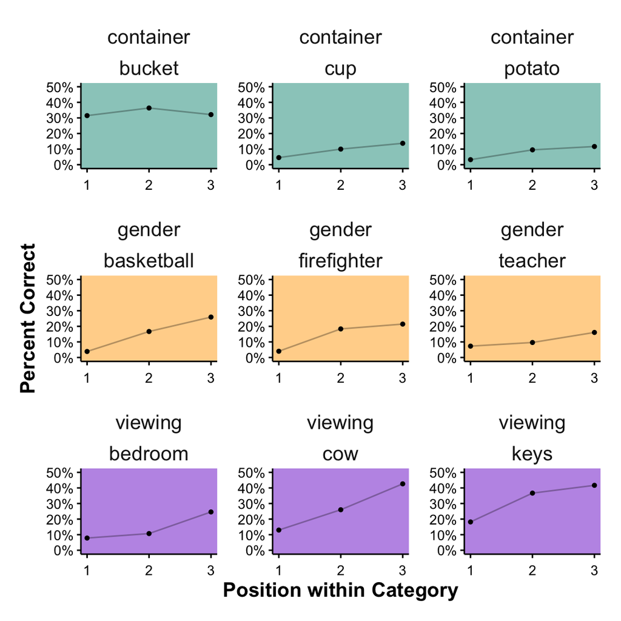

```r
riddle_accuracy <- df.stumpers %>%
  group_by(question_set, question_id, trial_order_within_set) %>%
  summarize(
    prop_correct = mean(is_correct, na.rm = TRUE),
    n = n()
  ) %>%
  ungroup()

riddle_accuracy %>%
  ggplot(aes(x = trial_order_within_set, y = prop_correct)) +
  geom_rect(aes(xmin = -Inf, xmax = Inf, ymin = -Inf, ymax = Inf,
               fill = question_set), alpha = 0.2) +
  scale_fill_manual(values = c("#009180", "orange", "#7600cf")) +
  geom_line(alpha = 0.3) +
  geom_point(size = 1) +
  facet_wrap(~ question_set + question_id, nrow = 3, scales = "free") +
  scale_y_continuous(labels = scales::percent,
                    limits = c(0, 0.5)) +
  scale_x_continuous(breaks = 0:2, labels=1:3) +
  labs(
    x = "Position within Category",
    y = "Percent Correct"
  ) +
  theme(
    strip.background = element_blank(),
    legend.position = "none",
    panel.spacing = unit(1, "lines")
  )
```

```r
# ggsave(here("results", "plots", "stumpers_accuracy_riddles_within_set.pdf"), dpi=300)
```

### Performance by category

```r
df.stumpers %>%
  mutate(correct = is_correct) %>%
  group_by(question_set, trial_order_within_set) %>%
  summarize(
    mean = mean(correct) * 100,
    sd = sd(correct) * 100
  )
```

| question_set | trial_order_within_set | mean | sd |
| --- | --- | --- | --- |
| container | 0 | 13.125 | 33.87 |
| container | 1 | 18.563 | 39.00 |
| container | 2 | 19.162 | 39.48 |
| gender | 0 | 5.096 | 22.06 |
| gender | 1 | 15.060 | 35.87 |
| gender | 2 | 21.084 | 40.91 |
| viewing | 0 | 13.125 | 33.87 |
| viewing | 1 | 24.699 | 43.26 |
| viewing | 2 | 35.882 | 48.11 |

### Performance by riddle

```r
df.stumpers %>%
  mutate(correct = is_correct) %>%
  group_by(question_id) %>%
  summarize(
    mean = mean(correct) * 100,
    sd = sd(correct) * 100
  )
```

| question_id | mean | sd |
| --- | --- | --- |
| basketball | 15.625 | 36.42 |
| bedroom | 14.881 | 35.70 |
| bucket | 33.333 | 47.28 |
| cow | 27.879 | 44.98 |
| cup | 9.697 | 29.68 |
| firefighter | 15.060 | 35.87 |
| keys | 31.902 | 46.75 |
| potato | 7.927 | 27.10 |
| teacher | 11.043 | 31.44 |

### Improvement on first set by age group

Calculate improvement ratios by age group and riddle category on first set, from trial 1 to trial 3

```r
df.stumpers %>%
  filter(trial_num %in% c(1,3)) %>%
  group_by(question_set) %>%
  mutate(age_group = age_months >= median(age_months, na.rm=TRUE)) %>%
    mutate(age_group = factor(age_group, levels=c(FALSE, TRUE), labels = c("younger", "older"))) %>%
  group_by(age_group, question_set, trial_num) %>%
  summarize(
    n = n(),
    acc = mean(is_correct, na.rm=TRUE),
    .groups="drop"
  ) %>%
  pivot_wider(names_from = trial_num, values_from = c(n, acc)) %>%
  mutate(improvement_ratio = acc_3/acc_1)
```

| age_group | question_set | n_1 | n_3 | acc_1 | acc_3 | improvement_ratio |
| --- | --- | --- | --- | --- | --- | --- |
| younger | container | 29 | 30 | 0.03448 | 0.10000 | 2.900 |
| younger | gender | 18 | 21 | 0.05556 | 0.09524 | 1.714 |
| younger | viewing | 23 | 27 | 0.04348 | 0.33333 | 7.667 |
| older | container | 29 | 34 | 0.10345 | 0.29412 | 2.843 |
| older | gender | 21 | 29 | 0.00000 | 0.24138 | Inf |
| older | viewing | 25 | 28 | 0.20000 | 0.53571 | 2.679 |

## Age by trial and set order

Check full model with all age interactions against simplest model representing task structure:

```r
model_5 <- update(model_1, .~. + trial_order_within_set*set_order*age_scaled)
anova(model_1, model_5)
```

|  | npar | AIC | BIC | logLik | deviance | Chisq | Df | Pr(>Chisq) |
| --- | --- | --- | --- | --- | --- | --- | --- | --- |
| model_1 | 7 | 1240 | 1277 | -613.1 | 1226 | NA | NA | NA |
| model_5 | 10 | 1245 | 1298 | -612.4 | 1225 | 1.421 | 3 | 0.7005 |